# Publication Plots

Authors

Affiliations

Emily Markowitz

NOAA Fisheres Alaska Fisheries Science Center

Catherine Foley

NOAA Fisheres Northeast Fisheries Science Center

Published

September 14, 2024

# 1 Data Wrangling

```
[1] "research_field condensed: what is in 'Other': None"
```

```
data frame with 0 columns and 0 rows
```

```
[1] "gear_type condensed: what is in 'Other': None"
```

```
data frame with 0 columns and 0 rows
```

```
[1] "location condensed: what is in 'Other': None"
```

```
[1] "In classifiers, not in category: Other"
```

```
[1] "In category, not in : classifiers"
```

```
[1] "keywords condensed: what is in 'Other': (81 phrases) antifouling, attitudes, biams, biofouling, bobbins, checklist, closed system, conflicts, cpua, culling, depm, deposition, development, dfa, diffusion, eaf, efficiency, emotions, escape gaps, escapement, etp, evelopment time, fad, fads, feds, …
```

```
data frame with 0 columns and 0 rows
```

```
[1] "keywords_cond1 condensed: what is in 'Other': (21 phrases) Aerial, Bioenergetics, Camera, Citizen science, Conservation and management, Covid-19, Ecosystem-based fisheries management, Education and outreach, Epidemiology, Genetics and molecular sciences, Harmful algea bloom, Hook and line, Mach…
```

```
data frame with 0 columns and 0 rows
```

```
[1] "affiliations condensed: what is in 'Other': None"
```

```
data frame with 0 columns and 0 rows
```

```
[1] "affiliations_cond1 condensed: what is in 'Other': (1 phrases) Not-for-Profit"
```

```
data frame with 0 columns and 0 rows
```

```
[1] "affiliations_cond1 condensed: what is in 'Other': (6 phrases) NOAA, US Government, US Museums and Education, US Research Societies and Institutes, US State Government, US Universities"
```

```
data frame with 0 columns and 0 rows
```

# 2 Analaysis summary

**Gear Type**: 3D stereo camera (e.g., stereo-baited remote underwater video (S-BRUV)), Acoustics, Advanced Tech, Beach seine, Beam Trawl, Bongo net, Bottom Trawl, Fisher interviews, Fisheries-Dependant, Gillnets, Grab samples, Hook & Line, Ichthyoplankton, Longline, Multiple, None, Otter Trawl, Pelagic net, Poly Nor’Eastern, four-seam, hard bottom, high-rise bottom trawl (AFSC BTS AI & GOA), Stock assessments, Traps, Uncrewed surface vehicle saildrone, Video

**Research topic**: Bycatch, Catchability, Climate change, Combine Surveys, Combine with Dependant, Data availability, Design-based indicies, Ecosystem-based management, Editorial, Emerging Methods, Essential Fish Habitat, Food web model, Harvest Control Rules, Histology, Life History, Model-Based Indicies, MPA, Oceanography, Otolith, Outreach and Communication, Population Model, Recruitment, Reference points, Review, Sampling design, Socio-Econ, Species Distribution Model, Stock Assessment Model, Survey Design, Survey Mitigation, Survey Statistics, Uncertainty, Wind Farm mitigation

**Location**: Adriatic Sea, Arafura Sea, Azores, Baltic Sea, Barents Sea, Brazil, Caribbean, Celtic Sea, China, Coral Sea, Eastern Indian Ocean, English Channel, Global, Great Australian Bight, Greater North Sea, Gulf of Mexico, Hawaii, Iberian Coast, Mediterranean Sea, Mid-NW Atlantic, NE Atlantic, NE Pacific, NW Atlantic, Pacific West Coast, Russia, Simulation, South-NW Atlantic, South Africa, Southern Ocean, Tasman Sea

**Survey**: ADFG - Southeast AK Sabelfish Longline Assessment; AFSC ATS - eastern Bering Sea; AFSC BTS - Aleutian Islands; AFSC BTS - Bering Sea Slope; AFSC BTS - eastern Bering Sea; AFSC BTS - Gulf of Alaska; AFSC BTS - northern Bering Sea; AFSC EcoFOCI ichthyoplankton survey - eastern Bering Sea; AFSC Observer; Azorean bottom longline survey; Baltic International Trawl Survey; BASS - hydroacoustic surveys Baltic Acoustic Spring Survey; BIAS - Baltic International Acoustic Survey; BITS - Baltic International Trawl Survey; Brazil longline survey; CA Pelagic shark longline survey; CalCOFI; CCES - SWFSC nearshore acoustics California Current Ecosystem Survey; Channel Ground Fish Survey; China - East China Sea; China - Haizhou Bay; China - Shandong Peninsula; China - Yangtze River estuary; CSIRO; DFO BTS - Scotian Shelf summer bottom trawl survey; Europe; Georgia Department of Natural Resources’ Coastal Resources Division has used a stratified; Greater North Sea International Otter Trawl Survey; ICES Beam Trawl Survey; ICES UK - International Bottom Trawl Survey; IPHC - Halibut Longline Assessment; MARMAP - Chevron Trap Survey; MARMAP - various gear; MEDITS - EU-funded MEDIterranean Trawl Survey; NEFSC BTS; NEFSC Gulf of Maine Bottom Longline Survey; NEPTUNE cabled observatory; NMFS COASTSPAN Apex Predator Investigation; NMFS SEAMAP Reef Fish Video Survey, the NMFS Panama City (Florida) survey, and the Fish and Wildlife Research Institute of the Florida Fish and Wildlife Conservation Commission survey; Northern Ireland Ground Fish Survey; NWFSC BTS; NWFSC DFO ATS Hake; NWFSC Observer; PRS - NWFSC coastal cooperative pre-recruit survey; Queensland scallop survey; RREAS - SWFSC Rockfish Recruitment and Ecosystem Assessment Survey; SEAMAP; SERFS - Southeast Reef Fish Survey; SESSF; Simulation; Study; TINRO; TPWD - Texas Parks and Wildlife Department

**Organism focus**: Clams, Crab, Ecosystem, Fish, ichthyoplankton, Lobster, Reef fish, Scallops, Sea Turtles, Shark, Simulation, Varied

# 3 Analysis on categories

## 3.1 Affiliations Cond1

### 3.1.1 Non-cumulative Line Plot

[figure not shown]

Line plot of frequency and year, by affiliations cond1.

### 3.1.2 Non-cumulative Bar Plot

[figure not shown]

Bar plot of frequency and year, by affiliations cond1

### 3.1.3 Non-cumulative Area Plot

[figure not shown]

Area plot of frequency and year, by affiliations cond1

### 3.1.4 Cumulative Line Plot

[figure not shown]

Line plot of cumulative frequency of affiliations cond1

### 3.1.5 Cumulative Bar Plot

[figure not shown]

Bar plot of cumulative frequency of affiliations cond1

### 3.1.6 Cumulative Area Plot

[figure not shown]

Area plot of cumulative frequency of affiliations cond1

### 3.1.7 Word Cloud

[figure not shown]

### 3.1.8 Summary table

Category

Frequency

20-year Trend

p-value

r^2

Trend

US Universities

1,471

0.000

0.808

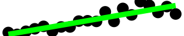

NOAA

451

0.000

0.649

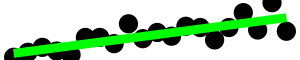

US Government

350

0.029

0.237

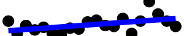

Australia Universities

207

0.007

0.361

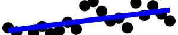

France Research Societies and Institutes

168

0.052

0.216

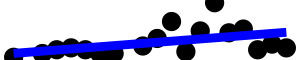

Australia Government

165

0.040

0.226

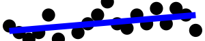

Other

156

0.003

0.440

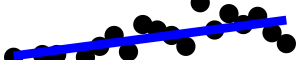

Canada Universities

118

0.036

0.234

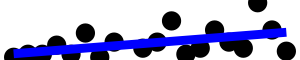

Spain Government

117

0.029

0.317

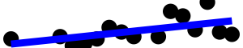

US State Government

100

0.009

0.372

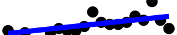

Canada Government

89

0.001

0.475

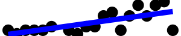

United Kingdom Research Societies and Institutes

89

0.142

0.122

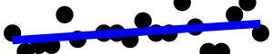

China Research Societies and Institutes

80

0.034

0.347

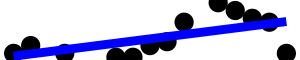

China Universities

75

0.020

0.374

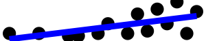

France Universities

72

0.363

0.064

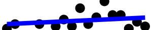

United Kingdom Universities

61

0.241

0.080

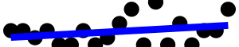

Scotland Universities

54

0.021

0.325

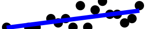

Italy Research Societies and Institutes

49

0.227

0.158

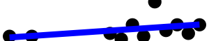

Norway Research Societies and Institutes

49

0.310

0.079

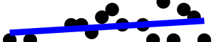

Germany Research Societies and Institutes

46

0.637

0.021

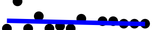

Denmark Universities

43

0.577

0.032

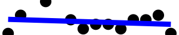

Japan Research Societies and Institutes

41

0.791

0.007

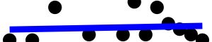

Spain Universities

40

0.146

0.182

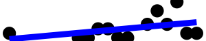

US Museums and Education

40

0.377

0.079

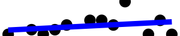

Sweden Universities

39

0.153

0.193

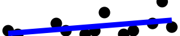

Brazil Universities

36

0.027

0.402

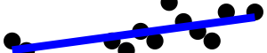

Germany Universities

32

0.250

0.130

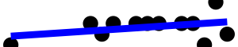

Not-for-Profit

32

0.115

0.210

Japan Universities

31

0.853

0.004

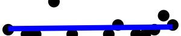

South Africa Universities

31

0.362

0.093

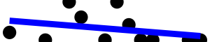

Italy Universities

30

0.675

0.015

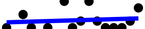

Portugal Universities

29

0.578

0.036

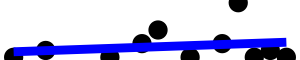

International governance

26

0.220

0.113

US Research Societies and Institutes

23

0.330

0.079

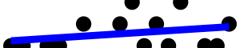

Netherlands Universities

21

0.798

0.008

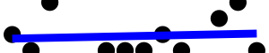

Canada Research Societies and Institutes

20

0.914

0.002

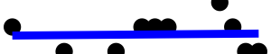

New Zealand Research Societies and Institutes

19

0.432

0.079

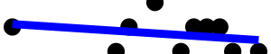

Norway Universities

19

0.429

0.107

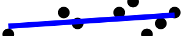

China Government

13

0.672

0.039

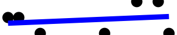

New Zealand Universities

13

0.484

0.063

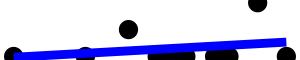

South Korea Universities

13

0.843

0.015

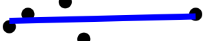

South Africa Government

12

0.544

0.099

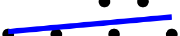

South Africa Research Societies and Institutes

12

0.557

0.073

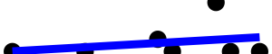

Argentinia Government

11

0.543

0.099

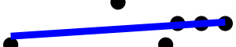

India Research Societies and Institutes

11

0.667

0.250

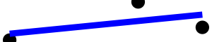

Southern Ireland Universities

11

0.140

0.739

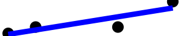

Chile Universities

10

0.630

0.087

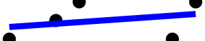

Greece Government

10

0.671

0.039

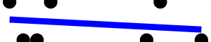

Greece Universities

10

0.425

0.131

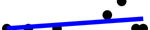

India Government

10

0.619

0.318

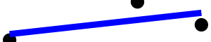

Mexico Research Societies and Institutes

10

0.322

0.242

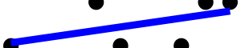

Mexico Universities

9

0.967

0.001

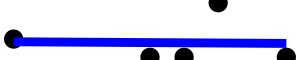

Scotland Research Societies and Institutes

9

0.355

0.214

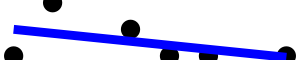

Argentina Universities

8

0.283

0.277

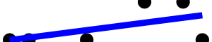

France Museums and Education

8

0.736

0.044

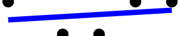

Private Industry

8

0.407

0.236